# Coding with an AI agent in VS Code

Week 9 lecture

Author

Affiliations

Jelmer Poelstra

[CFAES Bioinformatics Core, Ohio State University](https://go.osu.edu/bioinformatics-core)

[Dept. of Plant Pathology, Ohio State University](https://plantpath.osu.edu)

Presented on

October 19, 2026

Page last modified

October 23, 2026

## 1 Introduction

### 1.1 Learning goals

In this lecture, you will learn how to:

- Set up and use the Claude Code extension in VS Code Server at OSC
- Use Claude to ask questions about, write, and edit code, with your files as context
- Let Claude act as an “agent” that runs commands, and control what it may do with permission modes
- Give Claude persistent instructions (ones that carry over between conversations) with a `CLAUDE.md` file
- Keep a record of your AI use, with exported conversations and an AI diary
- Manage Claude’s context window and costs

### 1.2 From chat to agents

In the previous lecture, you used genAI through a browser-based chat. That works well for many questions, but when coding, it has clear limitations: the model can’t see your files unless you paste or upload them, and it can’t check whether the code it writes actually works.

Today, we’ll use **Claude Code**, Anthropic’s “agentic” coding tool. Working inside your editor, it can:

- **Read** the files in your project, so you don’t have to explain or paste them
- **Edit and create** files, showing you each change for approval
- **Run commands** in the terminal, for example to test a script or check a program’s help info

In other words, if browser chat is like emailing a knowledgeable colleague, working with an agent is more like having them sit next to you at your computer.

### 1.3 Why Claude Code in VS Code?

There are many AI coding tools, but this setup has two key advantages for us:

- **It’s approved for your research data.**  
  Rather than using a personal account, we’ll authenticate through an API key from OSU’s [Generative AI Service](https://it.osu.edu/generative-ai-service) , which is approved for use with restricted institutional data.
- **It integrates with our current VS Code setup.**  
  It only takes one extension, which you installed last week.

**NoteCode completions, GitHub Copilot, and other forms of Claude Code**

Another kind of AI coding help in IDEs is **code completions**: suggestions that appear in the editor as you type, and that you can accept with `Tab`. These either add new code (“ghost text” suggestions) or change code you already wrote (“next edit” suggestions). Claude Code does not offer code completions, but some other tools do, like GitHub Copilot. **GitHub Copilot** is built into VS Code, including VS Code Server at OSC. If you want to try code completions, see the self-study page on GitHub Copilot.

Claude Code itself also comes in several forms, including a command-line program and a desktop app. Here, we’ll use its VS Code extension.

## 2 Getting set up

### 2.1 Prepare and open a dir for this week

1. At https://ondemand.osc.edu, start a VS Code session in `/fs/ess/PAS3493/people/$USER`.
2. In the terminal, create a dir for this week, and copy your FastQC script from week 7 into it:

   ```bash
   mkdir -p week09/scripts
   cp -v week07/scripts/fastqc.sh week09/scripts/
   ```

   ```
   'week07/scripts/fastqc.sh' -> 'week09/scripts/fastqc.sh'
   ```

   (If you’re worried your own FastQC script is not correct or not complete, you can instead copy this version: `/fs/ess/PAS3493/share/week07/scripts/fastqc.sh`.)
3. **Open** the `week09` dir as your VS Code folder with `File` > `Open Folder`.

   Claude treats the folder that is open in VS Code as its “**workspace**”: this is where it will look for files, and by default the only place where it can make changes. (Yet another application where good project organization, in the sense of having a single self-contained dir with all project files, pays off.)

### 2.2 Claude Code setup (done last week)

Last week, you installed the Claude Code extension and connected it to your API key. If you’re not able to open Claude Code, or Claude doesn’t respond to a prompt, follow the steps in the box below.

**NoteSetting up Claude Code *(Click to expand)**

**Install the Claude Code extension**

1. In the **Extensions** side bar, search for “claude”, and click **Install** for the extension “**Claude Code for VS Code**”:

[figure not shown]

2. In the pop-up that asks whether you trust the publisher “Anthropic”, click **Trust Publisher & Install**:

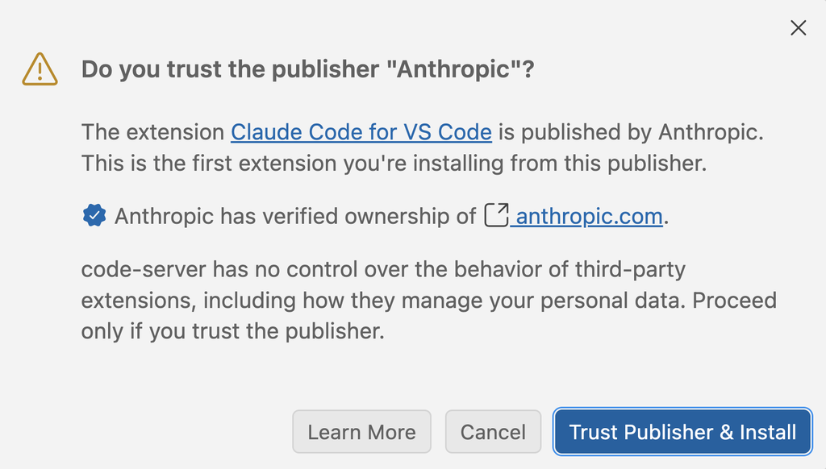

**Connect Claude to your API key**

You’ve received a **personal API key** from us, giving you access to Claude models through OSU’s Generative AI Service.

To tell Claude to use your key, you need to create a **settings file** in your Home dir. Claude expects this file to be a JSON file at the standard location `~/.claude/settings.json`, and will read that file every time it starts up. Let’s set this up:

1. Copy a template settings file to that location:

   ```bash
   mkdir -p ~/.claude
   cp -v /fs/ess/PAS3493/share/claude/settings.json ~/.claude/settings.json
   ```

   ```
   '/fs/ess/PAS3493/share/claude/settings.json' -> '/users/PAS0471/jelmer/.claude/settings.json'
   ```

2. Open your copy of the settings file in the editor[^1].
3. In the file, **replace the placeholder** `<API-KEY>` with your personal API key in the manner shown below:

   ```
   ~/.claude/settings.json (excerpt - before)
   ```

   ```
     "ANTHROPIC_AUTH_TOKEN": "<API-KEY>",
   ```

   ```
   ~/.claude/settings.json (excerpt - after - with fictional API key)
   ```

   ```
     "ANTHROPIC_AUTH_TOKEN": "bY-7jiuWbfck9DZk34hA_t",
   ```

**NoteMore about the settings file *(Click to expand)**

Here is what the file looks like before you add your own key:

```
~/.claude/settings.json
```

```json
{
  "env": {
    "ANTHROPIC_BASE_URL": "https://litellm.cloud.osu.edu",
    "ANTHROPIC_AUTH_TOKEN": "<API-KEY>",
    "ANTHROPIC_DEFAULT_OPUS_MODEL": "claude-opus-5-5",
    "ANTHROPIC_DEFAULT_SONNET_MODEL": "claude-sonnet-5",
    "ANTHROPIC_DEFAULT_HAIKU_MODEL": "claude-haiku-5-5",
    "CLAUDE_CODE_DISABLE_EXPERIMENTAL_BETAS": "1"
  },
  "model": "sonnet",
  "effortLevel": "medium",
  "outputStyle": "Concise",
  "theme": "auto"
}
```

The file is in JSON format, a plain-text format with key-value pairs: a colon `:` separates each key from its value, pairs are separated by commas, and curly braces `{}` group pairs. A single missing quote or comma breaks the whole file (this would be a likely culprit if Claude doesn’t pick up your API key).

- `ANTHROPIC_BASE_URL` makes Claude go through OSU’s service rather than directly to Anthropic.
- `ANTHROPIC_AUTH_TOKEN` is the API key.
- The `MODEL` lines specify which model versions to use.
- `model` and `effortLevel` set the default model (Sonnet) and effort level (Medium).
- `outputStyle` makes Claude’s answers shorter and more to the point (remove this line if you prefer longer explanations).

**ImportantTreat the API key like a password**

Anyone with your key can use it, and usage costs money and depletes your key’s budget. So never share your key or commit it to a Git repository. That’s one reason the settings file is located in your Home dir, and not in a project dir that others can see.

**A quick test**

You can type a prompt (question) in the prompt box in the Claude Code panel, and press `Enter` to send it to Claude[^2]. To check that Claude works, try this prompt:

> *Write a limerick about a grad student whose shell script keeps failing*

If you get a limerick back, Claude is set up correctly. If you get an error instead, or it **merely keeps printing verbs** like “Brewing” and “Deliberating” (Claude’s variant on a spinning wheel) but nothing else, let us know, and we’ll help you troubleshoot.

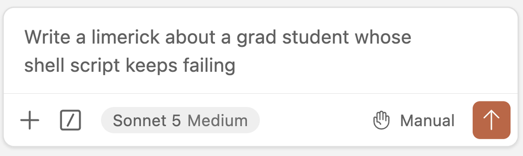

Write or paste the prompt in the box, and press `Enter`.

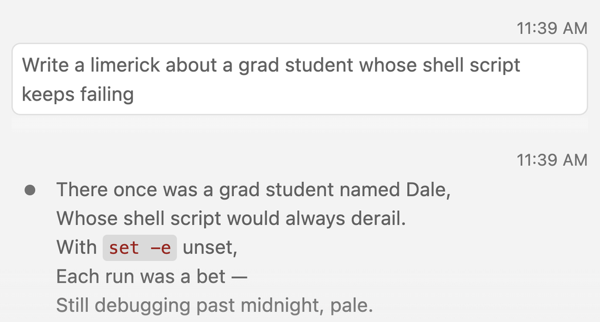

Then, your question and, after a while, the answer should appear in the panel above the prompt box.

### 2.3 Open Claude

This time, let’s open Claude Code in a slightly different way than last week, namely as a **tab in the editor** rather than in the side bar (see the box below). Do so by clicking the orange “splash” **Claude icon** in the top right corner of the editor pane.

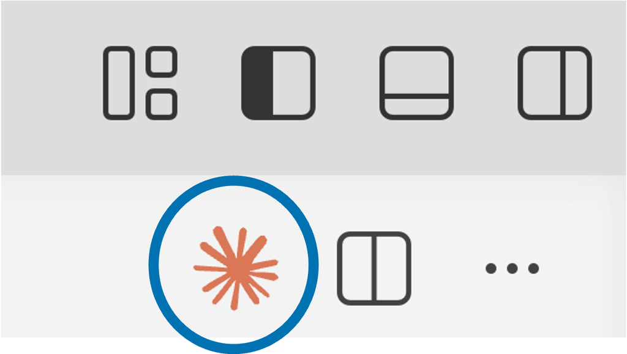

In the Claude Code panel, you may initially see various login options presented, like in the previous lecture (left screenshot below), but if you **simply wait**, Claude should read your settings file automatically and the panel should show a prompt box (right screenshot below):

[figure not shown]

If the panel looks something like this, you’re not yet authenticated with your API key. Simply wait, and Claude should read your settings file automatically.

[figure not shown]

If the panel looks something like this, you’re good to go! The important thing is that you see a **prompt box** at the bottom of the panel, whereas the message shown in the center is just one of many “tips” Claude may show.

**NoteThe two ways to open Claude Code *(Click to expand)**

We just opened Claude Code as a **tab in the editor**, which is slightly different from opening it in the **side bar**, like we did last week.

First, let’s see again how to open it in the side bar instead:

1. Open the “**secondary side bar**” by clicking the right-most icon in the top-right, which looks like a window split into two panes (see the screenshot on the right). This is a dedicated side bar for AI tools like Claude and GitHub Copilot.

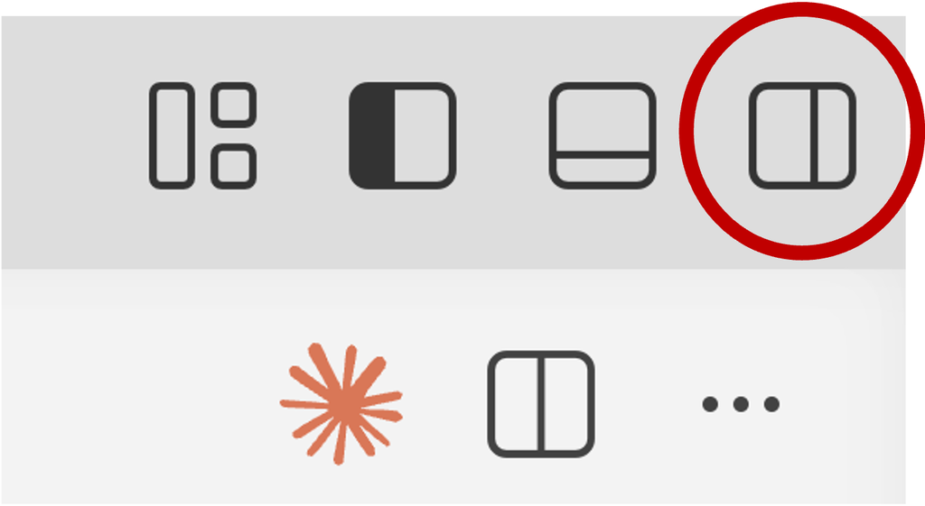

2. Because you activated GitHub Copilot in the previous lecture, both the Copilot tab (“**`CHAT`**”) and the Claude tab (“**`CLAUDE CODE`**”) should be visible if the side bar is made wide enough:

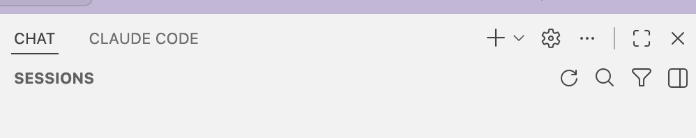

The two key differences between these two ways of opening Claude Code are:

- When it is open in the **side bar**, it will take up the full height of the window, whereas when it’s open as a tab in the editor, it will only take up the height of the editor pane, with the terminal below it.
- When it is open as a **tab in the editor**, you can have **multiple Claude tabs** open at once: simply click the Claude icon again to open a new tab. This can be useful for going back-and-forth between two conversations.

The screenshot below demonstrates both of these differences, with two Claude tabs open in the editor, the side bar open to the right of them, and the terminal below the editor pane:

[figure not shown]

## 3 Basics of the interface

### 3.1 The prompt box

Most of what you’ll do with Claude starts from the prompt box:

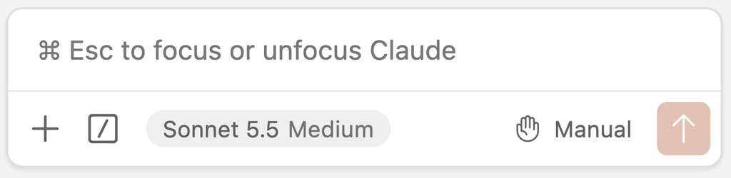

### 3.2 Managing conversations

You can manage your conversations using buttons at the top of the panel, as shown in this screenshot:

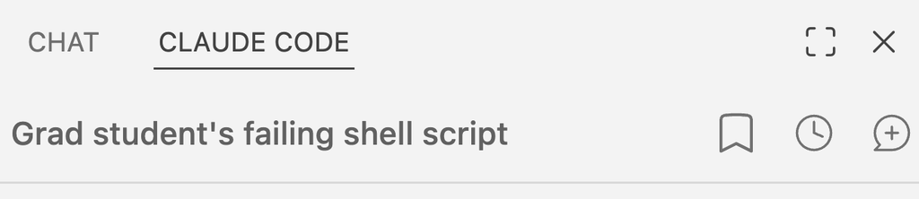

From left to right:

- The **bookmark** icon lets you access specific answers from Claude that you previously bookmarked (using a similar icon that appears below an answer when you hover over it).
- The **clock icon** lists your previous conversations, in case you want to return to one[^3].
- The **chat icon** with a `+` starts a new conversation. Start a new one for **each new task** (you’ll see why later).

**TipThe exact interface is ever-changing**

For example, the bookmarking feature was added in a recent update. These screenshots were made just days before class, and are likely to reflect what we’ll see in class, but you may well see differences in a later version of the extension.

## 4 An example: Having Claude write a script

### 4.1 Ask Claude to write a script

Start a new conversation with the new-conversation icon (top right of the panel), and submit the following prompt:

> *Write a script scripts/count_reads.sh that counts the number of reads in a* *gzipped FASTQ file. The FASTQ file should be an argument to the script.* *Keep it simple, I am a beginner in the shell*

Claude will show you what it’s doing as it goes, and it will likely **ask you for permission** to run a command, like in the screenshot on the right, where it first wanted to check whether the `scripts` dir (where we asked it to put the script) exists, and create it if not.

Try to understand what it is proposing to do, and click **Yes** to let it run the command.

In general, Claude loves to use **shell commands** for many tasks, so what you’ve learned in this course gives you a leg up in understanding what it does.

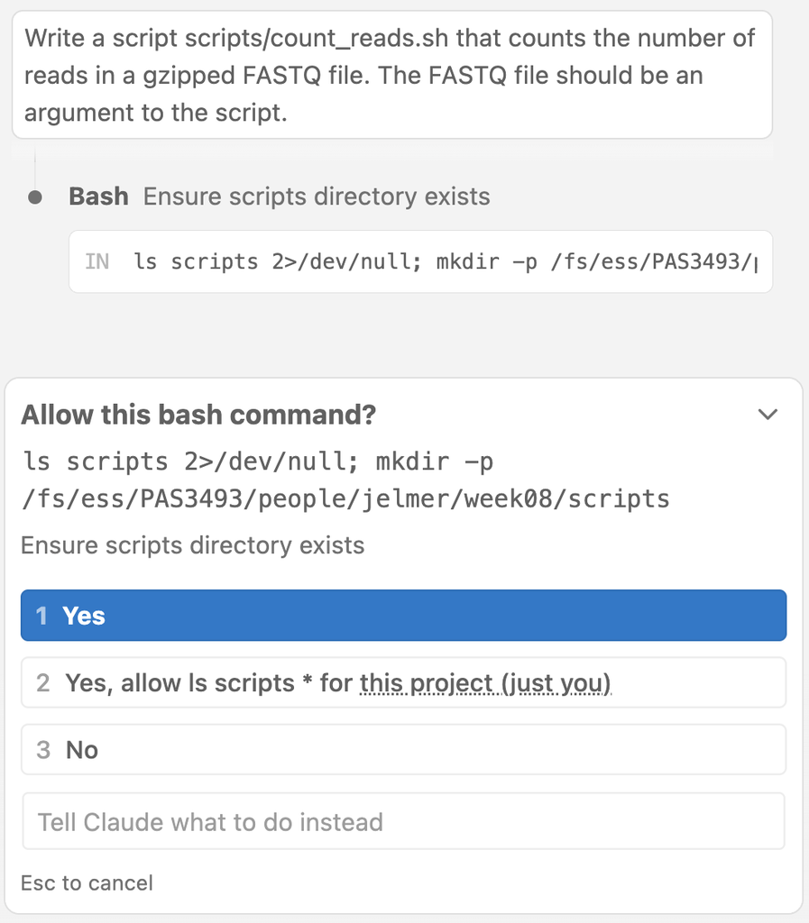

It should then **ask for permission** to create the script file, and show the proposed contents in the “diff” format we’ve seen before:

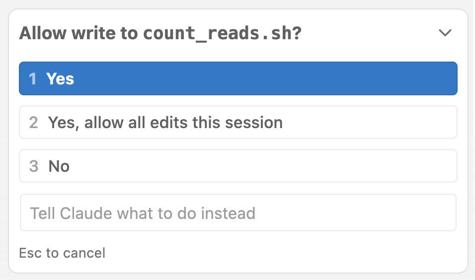

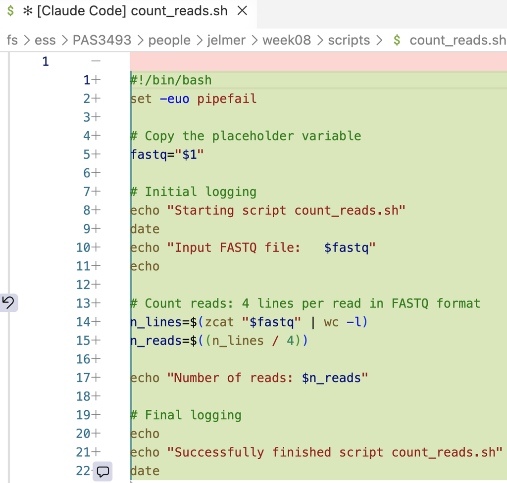

You can accept the change, decline it, or decline it and tell Claude what to do differently. Take a quick look and accept it (you’ll take a closer look in the upcoming exercise).

*(The screenshot above is from a run without the “Keep it simple” line,* *so your script is likely shorter and simpler.)*

Claude may also ask to make the script **executable** with `chmod +x`, and if so, you can allow it to do that as well.

*(Making scripts executable is not really necessary,* *so we didn’t practice with this in class.* *But it can be a convenience in some contexts —* *see this box from week 7 for more.)*

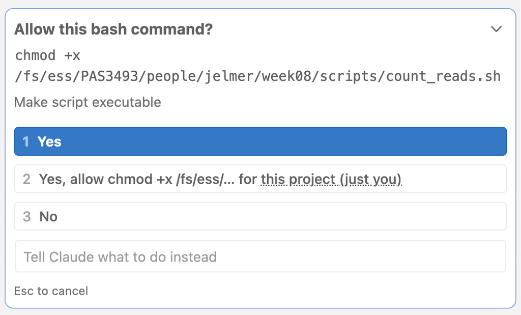

When Claude is done, it may close the script in the editor pane, but it should provide a clickable link in the panel:

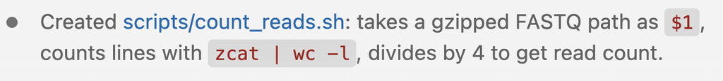

#### Exercise 1: Trying out Claude Code (breakout rooms)

*To start, pick one person that will share their screen,* *then work through the below questions collaboratively.*

1. Discuss the script Claude wrote:
   - Does the script look reasonable? Do you understand every line? It’s likely you don’t, because the script probably uses a few constructs that were only discussed in optional reading material (command substitution and bash arithmetic). You can ask Claude to explain any line you don’t understand.
   - If you’re not sharing your screen, check for differences with the script that *you* got, and discuss these.
   - Did Claude look at other files in your workspace before writing the script? If so, does that seem to have affected the way it wrote the script? If not, how does the script compare to the `fastqc.sh` script we wrote in week 7, for example in terms of structure, header lines, and so on?

   **Click here for a hint**

   When I ran the prompt without the “Keep it simple” line, Claude reported finding the `fastqc.sh` script in the `scripts` dir, and said it would copy the style of that script:

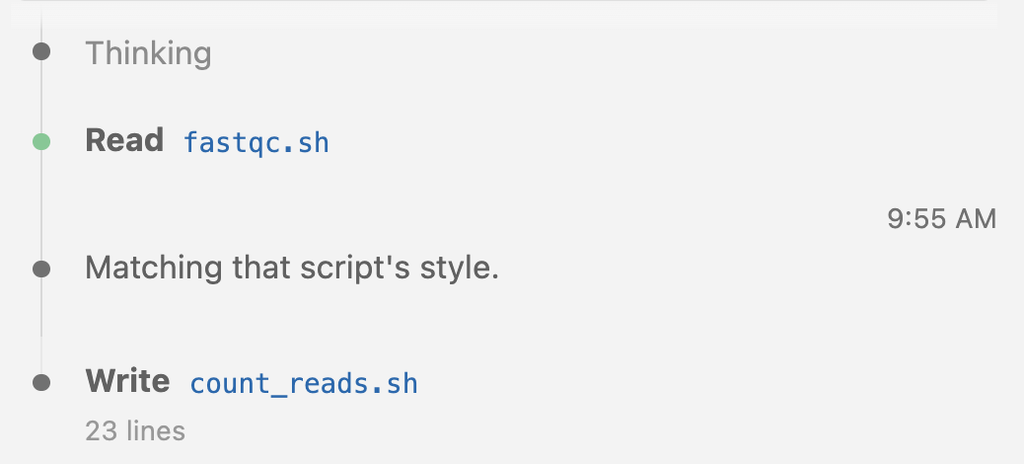

   The resulting script (shown in the screenshot further up) indeed very closely resembles the `fastqc.sh` script in its structure. With the “Keep it simple” line, Claude seems more likely to write a shorter script without these bells and whistles. You can test this yourself in the self-study exercise below this one.
2. Run the script on one of the FASTQ files, like `../garrigos/fastq/S63_R1.fastq.gz`. Did it work and can you check whether the number it reports is correct?

   **Click here for some hints**

   Here is how you can run the script for that file:

   ```bash
   bash scripts/count_reads.sh ../garrigos/fastq/S63_R1.fastq.gz
   ```

   The correct number of reads is 500,000, and this can be checked with `zcat` and `wc -l`:

   ```bash
   zcat ../garrigos/fastq/S63_R1.fastq.gz | wc -l
   ```

   ```
   2000000
   ```

   The number of reads is the number of lines (2,000,000) divided by 4.
3. We realize that we want to get a read count for each of the FASTQ files, so it might be useful to have the script print the file name along with the read count. Assuming your script doesn’t already do that, ask Claude to change the script:

   > Change the output so it only prints the file name and the number of reads, separated by a space

   As you’d expect, Claude will realize you’re talking about the script it just wrote, and if you have the script open, Claude will also automatically add it as explicit “context” to your prompt: its filename is shown below the prompt box (more on this below).

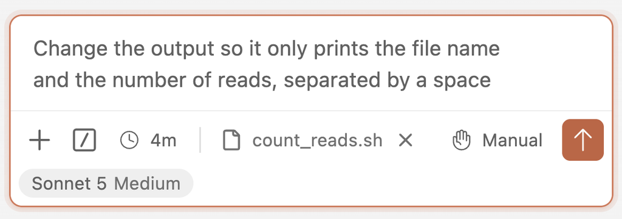

   `count_reads.sh` is automatically added as context to your prompt when you have the file open. The clock icon (`4m`) shows the time left before the cache expires (see Managing context and cost).
4. Do you understand how Claude shows the proposed changes to the script? And do you understand the actual changes it made to the script?

   **Click here for some hints**

   The screenshot on the right is the “diff” it showed for me, for the script written without the “Keep it simple” line, with proposed deletions (all the logging lines) highlighted in **red**, and additions (a single replacement line) highlighted in **green**. Your script is likely simpler and your diff smaller, but changes are shown in the same way.

   Those changes are in two separate places in the script, and each of them *can* be separately accepted or rejected by clicking the checkmark (✓) or backward arrow (↶) in the added gray boxes below them.

   (On the other hand, if you click “Yes” in the Claude Code prompt box, it will accept all changes at once. That’s a more typical way of working, though it’s useful to know that you can accept or reject individual changes.)

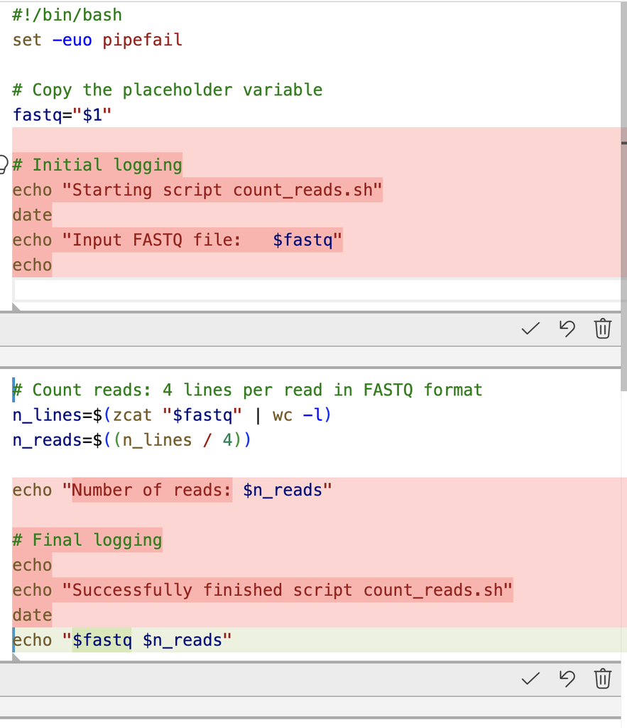

5. Ask Claude to make one more change:

   > Make the script accept multiple FASTQ files, and print one line per file

   Look at how Claude made the script accept multiple files, and try to understand this mechanism — you can ask Claude (or Gemini) to explain it. And does it use a `for` loop like we did in week 7?

   **Click here for a possible script**

   It’s likely that it will loop over files with `"$@"`, which is a special variable that expands to all arguments given to the script. This is really handy when you don’t know how many files will be given to the script.

   ```
   scripts/count_reads.sh
   ```

   ```bash
   #!/bin/bash
   # Usage: count_reads.sh <fastq.gz> [fastq.gz ...]

   # Loop over all FASTQ files given as arguments ("$@").
   for fastq_file in "$@"; do
       # Each read in a FASTQ file takes up 4 lines, so divide the line count by 4.
       num_lines=$(zcat "$fastq_file" | wc -l)
       num_reads=$((num_lines / 4))

       echo "$fastq_file $num_reads"
   done
   ```

6. With a single command, run the script on all Garrigos R1 files at once.

   **Click here for the solution**

   ```bash
   bash scripts/count_reads.sh ../garrigos/fastq/*_R1.fastq.gz
   ```

   This should print 22 lines, one for each sample.
7. *Optional*: Reflect on the difference between running the same task on many files with a `for` loop **inside** the script (as Claude likely did here) versus **outside** the script (like we did in week 7).

   **Click here for some hints**

   It’s probably clear that putting the loop in the script is more convenient in some ways: now, your script does all the heavy lifting, and you’ll be able to run it with a simple command (instead of having to write the loop outside of the script, potentially multiple times if you run the script multiple times).

   While we haven’t practiced with that yet, I have mentioned that in many cases, we’ll eventually want to run scripts by submitting them as batch jobs. What would a key difference be in that case? Would it still be advantageous to have the loop inside the script?

   Given that, when does it make sense to have the loop inside the script, and when does it make sense to have it outside?

#### Self-study exercise 1: Without “Keep it simple”

How much difference did the “Keep it simple” line in our prompt make? To find out, have Claude write the script again without that line.

1. Move your `count_reads.sh` script out of the workspace, so that Claude won’t find it and copy its style:

   ```bash
   mv scripts/count_reads.sh ~
   ```

   If you’re doing this exercise after class, also move your `CLAUDE.md` out of the workspace, since its script conventions would affect both versions of the script:

   ```bash
   mv CLAUDE.md ~
   ```

2. Start a **new conversation** with the new-conversation icon (otherwise, Claude would still “remember” the first script), and submit the original prompt with a different script name and without the “Keep it simple” line:

   > Write a script scripts/count_reads2.sh that counts the number of reads in a gzipped FASTQ file. The FASTQ file should be an argument to the script.
3. Move your first script (and, if needed, your `CLAUDE.md`) back, so you can look at both scripts side by side:

   ```bash
   mv ~/count_reads.sh scripts/
   mv ~/CLAUDE.md .    # only if you moved it in step 1
   ```

4. Compare the two scripts. Keep in mind that you changed `count_reads.sh` in Exercise 1, so focus on their overall style and structure:
   - Did Claude look at other files in your workspace this time?
   - Which script is easier to read and understand?
   - Run both scripts without any arguments: which one handles that better?
   - Which one would you rather use in a research project?

**TipThese prompts were deliberately simple**

They let us focus on understanding how the tool works, and see what it does when we’re not very specific about what we want. But if you know what you want, or have information that might help Claude help you figure that out, it’s often worth giving more context and detail, as discussed in the previous lecture.

## 5 Your files as context

### 5.1 Your workspace is the context

A key advantage of using AI inside your editor is that your files are readily available: you don’t need to upload or copy-and-paste them. Your entire **workspace** (the folder open in VS Code) is “implicit” context: when Claude thinks it’s useful, it will search and read files there by itself.

However, when you have a specific task and specific files in mind, it’s often better to point Claude to the relevant files **explicitly**. That’s faster and cheaper, and avoids Claude making assumptions about which files you mean.

### 5.2 Adding files and code to your prompt

- **The file that’s active in the editor** is added automatically. You can see this below the prompt box (to remove the file as context, click the `x` next to it).

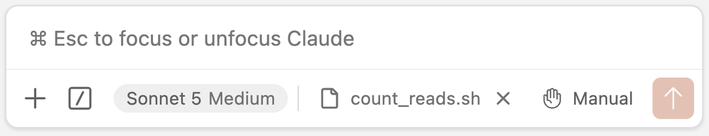

  Because `count_reads.sh` is the active file in the editor, it’s been automatically added as context to the prompt.
- **Selected lines** in the editor are also added automatically. This is handy to ask about specific lines in a longer script:

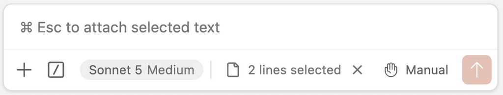

- **Type `@`** followed by part of a file name to add any file in your workspace, including files in subdirs. You can also wait for the list to appear after typing `@`, as shown in the screenshot below.

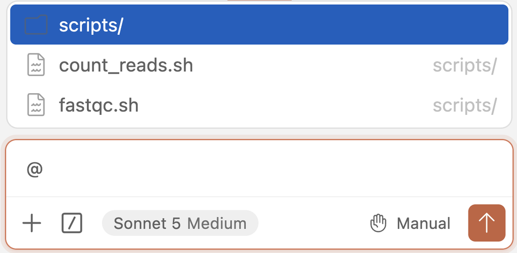

- When you switch to a different file in the editor, the automatically added file is *swapped* for the new one, so the previous file is no longer attached to your next prompt (though anything Claude already read is still part of the conversation). To add **multiple files**, type `@` (see above), or press `Alt/Option`+`K` while in a file: this inserts an `@`-mention of that file (or of the selected lines) into your prompt, so it stays in context when you switch to another file.

**NoteThe `+` button *(Click to expand)**

You can also add context with the `+` button below the prompt box. This also lets you upload files from your own computer.

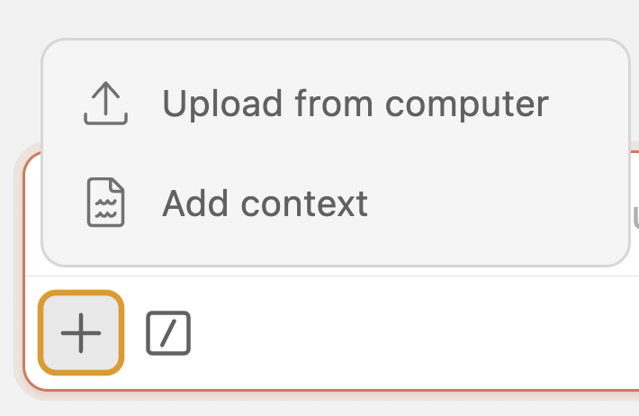

#### Exercise 2: Ask about your code

1. Start a new conversation. Then, open your `scripts/fastqc.sh` (copied from week 7) in the editor, and ask Claude:

   > Explain what this script does

   Does its explanation match your own understanding?
2. First, predict whether your `fastqc.sh` would still work if a FASTQ file name contained a space. Then, close all files in the editor, and ask Claude:

   > Which scripts in this project would break if a FASTQ file name contained a space?

   Watch how Claude finds the answer: which files does it look at? Does its answer match your prediction?

   **Click here for the solution**

   As long as every variable that holds a file name is double-quoted (e.g. `"$fastq"`), like in our week 7 script, a space in a file name is no problem. (You do still need to quote such a file name when you pass it to the script.)

   Note that our question assumed that some scripts *would* break. With such a “leading” question, Claude may go along with the assumption and point out problems that aren’t real. If its answer didn’t match your prediction, who was right? A more neutral way to ask is: *“Would any scripts in this project break if …?”*
3. *Optional:* The command below “accidentally” passes the two arguments in the wrong order. Run it:

   ```bash
   bash scripts/fastqc.sh results/fastqc ../garrigos/fastq/S63_R1.fastq.gz
   ```

   Copy your command *and* the error message into the prompt box, with the script still open (you can add a question like “What went wrong”, but this doesn’t tend to be necessary). Does its explanation make sense?

   **Click here for the solution**

   The script treats the FASTQ file as the output dir, so `mkdir -p` tries to create a dir `../garrigos/fastq/S63_R1.fastq.gz`. That fails with `File exists`, because a file with that name already exists, and `set -e` then stops the script before FastQC runs. The initial logging (`Input FASTQ file: results/fastqc`) is a strong clue to the cause. Claude may offer to add a check that the input file exists. That’s a reasonable improvement, but it’s your call whether to accept it.

## 6 Permission modes and running commands

### 6.1 Permission modes

The permission mode, shown at the bottom right of the prompt box, determines what Claude may do **without asking you first**. Click on it to switch between modes:

- **Manual**: Claude asks permission for each file edit and for many commands (it runs simple read-only commands, like `ls`, `head`, and `grep`, without asking, as you should have noticed in the previous exercises).
- **Edit automatically**: Claude edits files without asking, but asks about running commands just like in Manual mode.
- **Auto**: a separate AI model checks each action, whether it involves editing files or running commands, and Claude only asks you for permission for risky ones (see the box below).
- **Plan**: Claude only writes a plan, which opens as a Markdown document that you can review and modify before Claude carries it out. This is useful for bigger tasks and is covered in more detail in the self-study page on Claude Code.

**TipFor now, we’ll stick to Manual mode**

It’s slower-going, but you’ll see exactly what Claude does. Once you’re comfortable reviewing Claude’s work, though, the many permission requests can become tedious, and it’s easy to start clicking “Yes” without really reading what you approve.

At that point, “**Auto mode**” is a good alternative: routine actions, like editing files in your project, are then permitted without asking, while risky ones, like deleting many files or doing things you didn’t ask for, are blocked.

### 6.2 Letting Claude run commands

We’ve already seen how Claude runs commands, for example to check whether a directory or certain files exist. As you might expect, then, we can also ask Claude directly to run commands on our behalf. Let’s try the following prompt:

> *Run count_reads.sh on all FASTQ files in ../garrigos/fastq,* *and tell me which sample has the fewest reads*

Before running the script, Claude will show you the exact command and ask for permission, as we’ve seen before: approve its request. Here’s what I got in a test run: everything was done and interpreted correctly, including its inference that these reads were “subsampled to a fixed depth”:

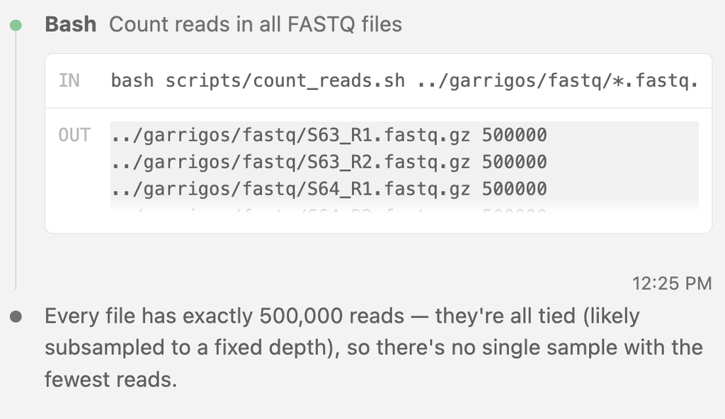

**WarningLetting Claude produce results vs. code**

In the example above, we’ve let Claude report a *result* directly, to see how it runs commands. For your research, this is **not** good practice, or at least it isn’t for producing final results you intend to report. Instead, your routine should be to have Claude write the *code* that produces your results, so that you can check, rerun, and keep it.

#### Self-study exercise 2: Let Claude fix a broken script

1. Create a new file `scripts/read_summary.sh` and paste the following into it. This script should count the number of reads in every FASTQ file in a dir, but it contains (at least) one error.

   **Click here to see the script**

   ```
   scripts/read_summary.sh
   ```

   ```bash
   #!/bin/bash
   set -euo pipefail

   # Copy the placeholder variables
   fastq_dir="$1"
   outfile="$2"

   # Initial logging
   echo "Starting script read_summary.sh"
   date
   echo "Input FASTQ dir:    $fastq_dir"
   echo "Output file:        $outfile"
   echo

   # Count the number of reads in each FASTQ file
   for fastq in "$fastq_dir/*.fastq.gz"; do
       n_lines=$(cat "$fastq" | wc -l)
       n_reads=$(( n_lines / 4 ))
       echo "$fastq $n_reads" >> "$outfile"
   done

   # Final logging
   echo "Successfully finished script read_summary.sh"
   date
   ```

2. Run the script, and take a look at the error:

   ```bash
   bash scripts/read_summary.sh ../garrigos/fastq read_summary.txt
   ```

3. In a new conversation, ask Claude to fix the script:

   > I ran `bash scripts/read_summary.sh ../garrigos/fastq read_summary.txt` and got [paste the error message here]

   Then watch what Claude does:
   - Does it explain the cause of the error, and do you understand the explanation?
   - Does it only fix the error you reported, or does it find and fix other problems too?
   - Does it run the script to test its fix?
4. If Claude did not test the script, run it yourself. Then check the contents of `read_summary.txt`: are the read counts correct? If the counts are not correct, tell Claude, and let it fix the script.

**Click here for a partial solution**

The script contains two errors:

- The glob in the `for` loop is inside double quotes (`"$fastq_dir/*.fastq.gz"`), so it is not expanded. The loop therefore runs only once, with the literal string `../garrigos/fastq/*.fastq.gz`, and `cat` fails because no file has that name. The fix is to keep the `*` outside the quotes: `"$fastq_dir"/*.fastq.gz`.
- The script uses `cat` instead of `zcat` on gzipped files. This doesn’t cause an error message: `wc -l` simply counts the “lines” in the compressed data, so the script reports read counts that are far too low. This is the more dangerous of the two errors, because it silently produces wrong results.

Claude may have noticed the second error by reading the script, after running it and seeing suspicious read counts, or not at all. This shows why a script that runs without errors still needs to be checked, whether you or Claude wrote or fixed it.

Finally, because the script appends (`>>`) to the output file, running it multiple times will add the same files again to `read_summary.txt`. Claude may have noticed this when testing the script, and either removed the file between test runs or changed `>>` to something else.

### 6.3 Stopping, steering, and rewinding

Sometimes you need to adjust what Claude is doing while it’s working. You can do that in the following ways:

- **Steer it**: When you realize your instructions were incorrect or incomplete in a minor way, or you can see from Claude’s intermediate output messages (it helps to **keep an eye on** these!) that it’s going down the wrong path, you can steer it. Type a new message while Claude is working, and it will take that into account after a few seconds. For example, give this prompt:

  > *Write a script scripts/fastqc_all.sh that loops over all FASTQ files in ../garrigos/fastq* *and runs scripts/fastqc.sh on each one, with output going to results/fastqc*

  Then, as it’s working, send it a new message:

  > *Actually, only do the R1 files*

  If you’re quick enough, it will take that into account before finishing the script. Otherwise, it will edit its script. Either way, you should see that it acknowledges your new instruction in its response, which it may do explicitly (by saying something like “*Got it. Will only …*” while working). Or it may do so implicitly, as shown below, where its final comments show it only loops over R1 files.

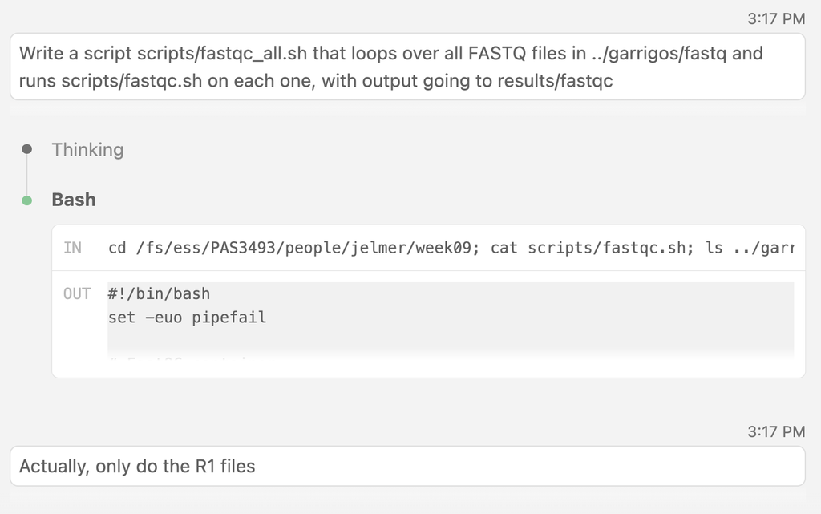

  While Claude was still working, I sent it a new message to change its instructions.

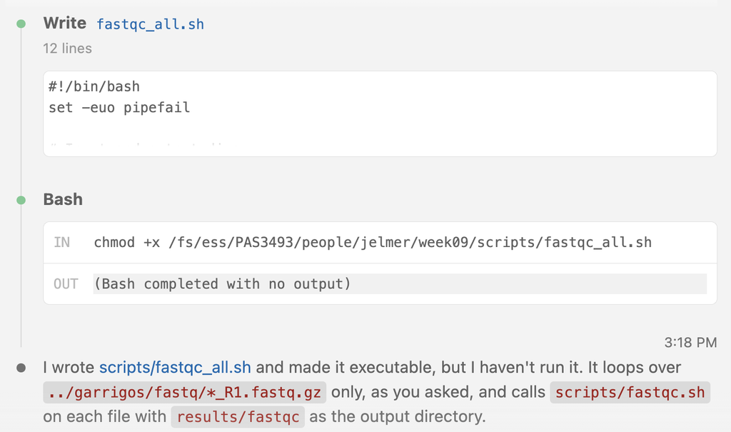

  It then takes these instructions into account after a few seconds. If it had finished the task in the meantime, it would then have edited the script to reflect the new instructions instead.

  **Click to see a screenshot for a different example**

  The message “actually load R 4.4.0 instead” was added while Claude was working, and you can see that it explicitly acknowledges the new instruction in a quick response:

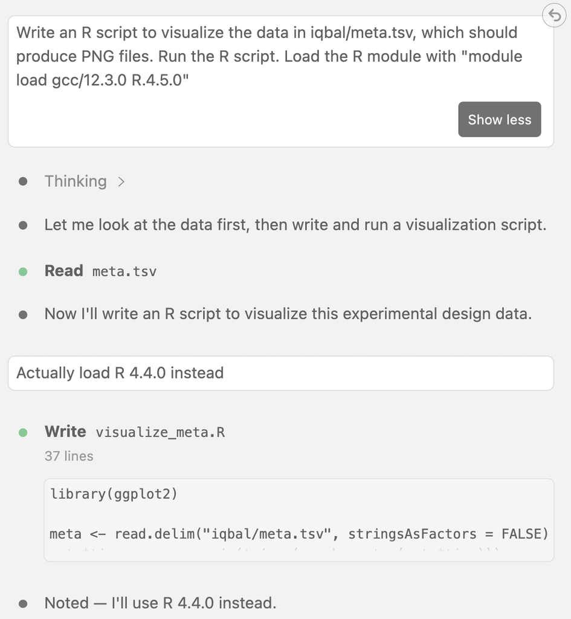

- **Stop it**: In other cases, you may simply want to stop Claude from continuing its current task. Perhaps your instructions were wrong, or you realize you want to do something else, or you can see that Claude is doing something you don’t want it to do at all. For example, in the same conversation, send:

  > *Write a README.md for this project that documents both scripts in detail*

  Let’s say we don’t actually want it to do that: press `Esc` or click the stop button while it’s working:

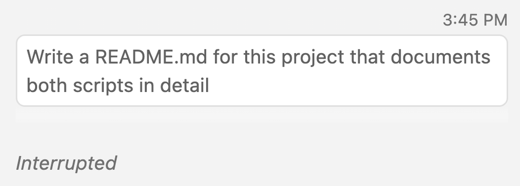

  “Interrupted” means that Claude stopped what it was doing, and will not continue.
- **Rewind**: You can also go back to an earlier point in the conversation, and undo any file changes along the way. To do this, press `Esc` twice in quick succession, or hover over one of your earlier messages and click the rewind button. You can try this now if Claude already created a (partial) README file before you stopped it. (Alternatively, note that Claude is also good at undoing things when you simply ask it to do so.)

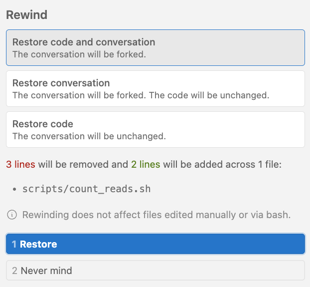

  When you try to rewind to a point in the conversation after which Claude made changes to files,  
  it will ask you whether to undo those code changes, just the conversation, or both.

## 7 Persistent instructions with `CLAUDE.md`

### 7.1 Why persistent instructions?

Each new conversation with Claude starts with an empty context window: it doesn’t see what you discussed in earlier conversations. So you may find yourself repeatedly telling it the same things, such as:

- “Run programs with Apptainer containers, not by installing them”
- “Never modify the raw data in `../garrigos`”
- “Follow these script conventions: …”

Rather than constantly repeating yourself, and having to write long prompts, you can put these kinds of instructions in a file called `CLAUDE.md` to make them “persistent” across conversations.

### 7.2 What is `CLAUDE.md`, and what to include in it

`CLAUDE.md` is a Markdown file that Claude **automatically reads** at the start of every conversation in your project. There is no required format, but it should be concise and easy to read, for you as well as for Claude[^4]. Typically, it’s placed in **a project’s root dir**, like our `week09` dir:

```
week09
├── CLAUDE.md
└── scripts
    ├── count_reads.sh
    ├── fastqc_all.sh
    └── fastqc.sh
```

Some useful things to include in a `CLAUDE.md` are:

- **Project overview**: the research question, organism, data type, and experimental design.
- **Project file structure**: where the raw data, scripts, and results are.
- **Conventions**: how you write scripts and name files.
- **Software**: how software is run (e.g., with containers) and which versions.
- **Rules and pitfalls**: things Claude should never do, or tends to get wrong.

**NoteDrafting a `CLAUDE.md` with `/init` *(Click to expand)**

Instead of writing a `CLAUDE.md` from scratch, you can type the **`/init`** command in the prompt box: Claude then looks through your project and drafts a `CLAUDE.md` for you to review and edit. (If a `CLAUDE.md` already exists, `/init` will instead suggest updates to it.)

This can be a useful start in a larger existing project. But in a small project like our `week09` dir, `/init` doesn’t have much to work with, so its draft would mostly describe the existing scripts — information Claude can also get by simply reading those scripts when needed. Even in larger projects, the most valuable parts of a `CLAUDE.md` are things only you know: what the project is about, where the data is, and how you want things done.

### 7.3 First example: pirate-speak

Create a new file `CLAUDE.md` in your `week09` dir, and open it:

```bash
touch CLAUDE.md
```

To see that Claude really reads this file, add the following line to it, and save the file:

```
CLAUDE.md
```

```markdown
- Always answer in the style of a pirate
```

Then, close the file (so we know it doesn’t just follow instructions based on explicit file context), start a new conversation, and ask:

> *What does `set -u` do in a shell script?*

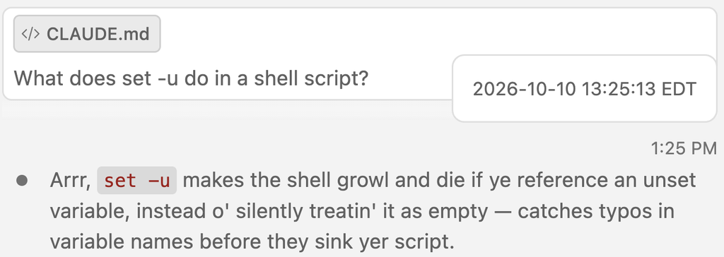

Followed by:

> *Why are you talking like that?*

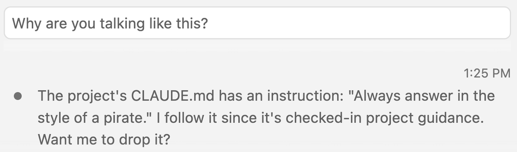

### 7.4 Second example: more serious instructions

Here’s a more serious set of instructions — copy-paste this into your `CLAUDE.md` file (replacing the pirate line):

```
CLAUDE.md
```

```markdown
# Practice RNA-Seq project

Practice project for the course PLNTPTH 5006, using RNA-Seq data from Garrigós et al.
(2025) on Culex pipiens mosquitoes infected with two avian Plasmodium species.

## Data

- FASTQ files are in `../garrigos/fastq`: paired-end, ~75-bp Illumina reads for
  22 samples, subsampled to 500,000 reads per file
- Sample metadata is in `../garrigos/meta/metadata.tsv`
- Never modify, move, or delete anything in `../garrigos`

## Project structure

- `scripts/`: scripts
- `results/`: all output, in a separate subdir for each step (e.g. `results/fastqc`)

## Computing infrastructure

- We work at the Ohio Supercomputer Center (OSC)
- I haven't yet learned how to submit batch jobs, so don't propose to use these
  (and therefore run programs with a single core/thread)

## Shell script conventions

- Start scripts with `#!/bin/bash` and `set -euo pipefail`
- Below that, add a comment block with the script's purpose and a usage line
  (e.g. `# Usage: bash scripts/fastqc.sh <FASTQ file> <output dir>`)
- Copy arguments to descriptively named, lowercase variables (e.g. `fastq="$1"`);
  use uppercase only for constants (e.g. `CONTAINER=...`)
- At the start, report the script name, the date, and the inputs;
  at the end, report the program version, a success message, and the date
- Create output dirs with `mkdir -p` before writing to them
- Strike a balance between script functionality and robustness vs. simplicity and
  readability: I am a shell beginner
- In script comments, briefly explain any non-obvious commands, options, and constructs
- Programs that aren't available in the system path should be run with Apptainer
  containers from Seqera Containers (`oras://` URLs),
  not with `module load` or by installing them
```

**NoteComment block with script purpose and usage *(Click to expand)**

You know most of the conventions in the above `CLAUDE.md` file from week 7, but the comment block below the first two lines is new. It’s good practice because it lets you (or anyone else) see what a script does and how to run it, without having to read through the code. For example, for the FastQC script from week 7:

```
scripts/fastqc.sh (excerpt)
```

```bash
#!/bin/bash
set -euo pipefail

# Run FastQC on one FASTQ file to check its quality
# Usage: bash scripts/fastqc.sh <FASTQ file> <output dir>
```